# IMPORT DATA FROM FLAT FILES WITH UTILS

Importing data into R should be the easiest step in your analysis. Unfortunately, that is almost never the case. Data can come in many formats, ranging from .csv and text files, to statistical software files, to databases and HTML data. Knowing which approach to use is key to getting started with the actual analysis.

[figure not shown]

### 1.1 read.csv

Flat files are typically simple text files that display data as tables. The standard distribution of R provides functionality in built-in **utils** package to import flat files into R as a data frame, which is loaded automatically when we start R. csv data is a flat file where csv stands for “comma separated values”. For example, import the *states.csv* file with `read.csv()` function. The first line gives the names of the different columns or fields. After that, each line is a record, and the fields are separated by a comma.

```r
df <- read.csv("states.csv", stringsAsFactors = TRUE)
df
```

```
##          state    capital pop_mill area_sqm
## 1 South Dakota     Pierre    0.853    77116
## 2     New York     Albany   19.746    54555
## 3       Oregon      Salem    3.970    98381
## 4      Vermont Montpelier    0.627     9616
## 5       Hawaii   Honolulu    1.420    10931
```

The structure nicely corresponds the data frame in R. The rows correspond to the records and the columns correspond to the fields. The field names are used to name the columns of the data frame. First argument is the path to the imported file or the file name in current working directory. Depending on which platform you are working on, Microsoft, Linux, Mac…, file paths are specified differently.

To build a path to a file in a platform-independent way, use `file.path()` function. Suppose the file is located in the `0_data` of the home directory:

```r
path <- file.path("~", "0_data", "states.cv")
path
```

```
## [1] "~/0_data/states.cv"
```

This path can now be used to point to the direct file.

Second argument `stringsAsFactors` chooses to import columns that contains strings as actual strings or as factors. By default, `stringsAsFactors = FALSE`.

```r
str(df)
```

```
## 'data.frame':    5 obs. of  4 variables:
##  $ state   : Factor w/ 5 levels "Hawaii","New York",..: 4 2 3 5 1
##  $ capital : Factor w/ 5 levels "Albany","Honolulu",..: 4 1 5 3 2
##  $ pop_mill: num  0.853 19.746 3.97 0.627 1.42
##  $ area_sqm: int  77116 54555 98381 9616 10931
```

To list the files in the working directory, use `dir()`.

Import *swimming_pools.csv* which contains data on swimming pools in Brisbane, Australia:

```r
pools <- read.csv("swimming_pools.csv")
str(pools)
```

```
## 'data.frame':    20 obs. of  4 variables:
##  $ Name     : chr  "Acacia Ridge Leisure Centre" "Bellbowrie Pool" "Carole Park" "Centenary Pool (inner City)" ...
##  $ Address  : chr  "1391 Beaudesert Road, Acacia Ridge" "Sugarwood Street, Bellbowrie" "Cnr Boundary Road and Waterford Road Wacol" "400 Gregory Terrace, Spring Hill" ...
##  $ Latitude : num  -27.6 -27.6 -27.6 -27.5 -27.4 ...
##  $ Longitude: num  153 153 153 153 153 ...
```

### 1.2 read.delim

Another common format of flat file data is the tab-delimited file, like *.txt* file. To import the same *states* data but in .txt format, we need `read.delim()` function.

```r
read.delim("states.txt")
```

```
##          state    capital pop_mill area_sqm
## 1 South Dakota     Pierre    0.853    77116
## 2     New York     Albany   19.746    54555
## 3       Oregon      Salem    3.970    98381
## 4      Vermont Montpelier    0.627     9616
## 5       Hawaii   Honolulu    1.420    10931
```

If the data comes in typical comma separated or tab-delimited format, importing flat files is an easy task. If not, you will have to do some more customization work. By default, `read.delim()` sets the `sep` argument to `\t` (fields in a record are delimited by tabs) and the `header` argument to `TRUE` (the first row contains the field names).

Import *hotdogs.txt* which contains information on sodium and calorie levels in different hotdogs:

```r
hotdogs <- read.delim("hotdogs.txt", header = FALSE)
```

The variable names are not on the first line. Print out some summary statistics about all variables in the data frame:

```r
summary(hotdogs)
```

```
##       V1                  V2              V3
##  Length:54          Min.   : 86.0   Min.   :144.0
##  Class :character   1st Qu.:132.0   1st Qu.:362.5
##  Mode  :character   Median :145.0   Median :405.0
##                     Mean   :145.4   Mean   :424.8
##                     3rd Qu.:172.8   3rd Qu.:503.5
##                     Max.   :195.0   Max.   :645.0
```

Specify the column types or column classes of the resulting data frame with `colClasses` argument:

```r
hotdogs <- read.delim("hotdogs.txt",
                      header = FALSE,
                      col.names = c("type", "calories", "sodium"),
                      colClasses = c("factor", "NULL", "numeric"))
str(hotdogs)
```

```
## 'data.frame':    54 obs. of  2 variables:
##  $ type  : Factor w/ 3 levels "Beef","Meat",..: 1 1 1 1 1 1 1 1 1 1 ...
##  $ sodium: num  495 477 425 322 482 587 370 322 479 375 ...
```

If a column is set to `NULL` in the `colClasses` vector, this column will be skipped and will not be loaded into the data frame. This approach can be useful if you have some columns that should be factors and others that should be characters. You don’t have to bother with `stringsAsFactors` anymore; just state for each column what the class should be.

### 1.3 read.table

If you’re dealing with more exotic flat file formats, you’ll want to use `read.table()` which allows you to read in any file in table format and create a data frame from it. For example, the same *states* data with the values being separated by `/` instead of `,` or `tab`.

```r
read.table("states2.txt",
           header = TRUE,
           sep = "/")
```

```
##          state    capital pop_mill area_sqm
## 1 South Dakota     Pierre    0.853    77116
## 2     New York     Albany   19.746    54555
## 3       Oregon      Salem    3.970    98381
## 4      Vermont Montpelier    0.627     9616
## 5       Hawaii   Honolulu    1.420    10931
```

The number of arguments is huge, some main ones are:

Import the *hotdogs.txt* again, this time with `read.table()` with an argument to name the columns:

```r
hotdogs <- read.table("hotdogs.txt",
           sep = "",
           col.names = c("type", "calories", "sodium"),
           stringsAsFactors = TRUE)
head(hotdogs)
```

```
##   type calories sodium
## 1 Beef      186    495
## 2 Beef      181    477
## 3 Beef      176    425
## 4 Beef      149    322
## 5 Beef      184    482
## 6 Beef      190    587
```

Next to calories and sodium, the hotdogs have one more variable: `type`. This is a categorical variable because it can be only one of three things: Beef, Meat, or Poultry. Select the hot dog with the least calories:

```r
hotdogs[which.min(hotdogs$calories), ]
```

```
##       type calories sodium
## 50 Poultry       86    358
```

Select the observation with the most sodium:

```r
hotdogs[which.max(hotdogs$sodium), ]
```

```
##    type calories sodium
## 15 Beef      190    645
```

### 1.4 Wrappers

`read.table()` is the main function of the **utils** package. `read.csv()` and `read.delim()` are so called *wrapper* functions around `read.table()`. Behind the scenes, `read.table()` is called, but with different default arguments to match the specific formats.

```r
read.csv("states.csv")
```

```
##          state    capital pop_mill area_sqm
## 1 South Dakota     Pierre    0.853    77116
## 2     New York     Albany   19.746    54555
## 3       Oregon      Salem    3.970    98381
## 4      Vermont Montpelier    0.627     9616
## 5       Hawaii   Honolulu    1.420    10931
```

is the same as:

```r
read.table("states.csv",
           header = TRUE,
           sep = ",",
           stringsAsFactors = FALSE)
```

```
##          state    capital pop_mill area_sqm
## 1 South Dakota     Pierre    0.853    77116
## 2     New York     Albany   19.746    54555
## 3       Oregon      Salem    3.970    98381
## 4      Vermont Montpelier    0.627     9616
## 5       Hawaii   Honolulu    1.420    10931
```

So you don’t have to specify manually these anymore. Wrappers are shorter and easier to read.

Likewise `read.delim()` is the same as:

```r
read.delim("states.txt",
           header = TRUE,
           sep = "\t")
```

```
##          state    capital pop_mill area_sqm
## 1 South Dakota     Pierre    0.853    77116
## 2     New York     Albany   19.746    54555
## 3       Oregon      Salem    3.970    98381
## 4      Vermont Montpelier    0.627     9616
## 5       Hawaii   Honolulu    1.420    10931
```

`read.csv2()` and `read.delim2()` exist to deal with regional differences in representing numbers. For example, `read.csv()` doesn’t always give the result we want, because the values are separated by a `;`, not a `,`.

```r
read.csv("states_nay.csv")
```

```
##                       state.capital.pop_mill.area_sqm
## South Dakota;Pierre;0                       853;77116
## New York;Albany;19                          746;54555
## Oregon;Salem;3                               97;98381
## Vermont;Montpelier;0                         627;9616
## Hawaii;Honolulu;1                            42;10931
```

Try again with `read.csv2()`:

```r
read.csv2("states_nay.csv")
```

```
##          state    capital pop_mill area_sqm
## 1 South Dakota     Pierre    0.853    77116
## 2     New York     Albany   19.746    54555
## 3       Oregon      Salem    3.970    98381
## 4      Vermont Montpelier    0.627     9616
## 5       Hawaii   Honolulu    1.420    10931
```

It works perfectly, because the default argument `sep = ";"`.

`read.delim2()` has a default argument to convert the European decimal system with `,` into the US `.`

```r
read.delim("states_aye.txt")
```

```
##          state    capital pop_mill area_sqm
## 1 South Dakota     Pierre    0,853    77116
## 2     New York     Albany   19,746    54555
## 3       Oregon      Salem    3,970    98381
## 4      Vermont Montpelier    0,627     9616
## 5       Hawaii   Honolulu    1,420    10931
```

```r
read.delim2("states_aye.txt")
```

```
##          state    capital pop_mill area_sqm
## 1 South Dakota     Pierre    0.853    77116
## 2     New York     Albany   19.746    54555
## 3       Oregon      Salem    3.970    98381
## 4      Vermont Montpelier    0.627     9616
## 5       Hawaii   Honolulu    1.420    10931
```

### 1.5 scan

When reading in spreadsheets many things can go wrong. The file might have a multiline header, be missing cells, or it might use an unexpected encoding. `scan()` helps you read-in each cell of a file.

```r
scan("states.csv", sep = ",", what = "c")
```

```
##  [1] "state"        "capital"      "pop_mill"     "area_sqm"     "South Dakota"
##  [6] "Pierre"       "0.853"        "77116"        "New York"     "Albany"
## [11] "19.746"       "54555"        "Oregon"       "Salem"        "3.970"
## [16] "98381"        "Vermont"      "Montpelier"   "0.627"        "9616"
## [21] "Hawaii"       "Honolulu"     "1.420"        "10931"
```

### 1.6 readr

In addition to base R, there are dedicated packages to easily and efficiently import flat file data. **readr** package which is written by Hadley Wickham is fast and easy to use with consistent naming, while **utils** is more verbose and multiple times slower.

```r
library(readr)
```

Import the *states.csv* file again with **utils** to compare the difference:

```r
read.csv("states.csv", stringsAsFactors = FALSE) # return a data frame.
```

```
##          state    capital pop_mill area_sqm
## 1 South Dakota     Pierre    0.853    77116
## 2     New York     Albany   19.746    54555
## 3       Oregon      Salem    3.970    98381
## 4      Vermont Montpelier    0.627     9616
## 5       Hawaii   Honolulu    1.420    10931
```

Similar function like `read.csv` in **readr** is `read_csv`:

```r
read_csv("states.csv")
```

```
## # A tibble: 5 x 4
##   state        capital    pop_mill area_sqm
##   <chr>        <chr>         <dbl>    <dbl>
## 1 South Dakota Pierre        0.853    77116
## 2 New York     Albany       19.7      54555
## 3 Oregon       Salem         3.97     98381
## 4 Vermont      Montpelier    0.627     9616
## 5 Hawaii       Honolulu      1.42     10931
```

The result is pretty much the same. The only difference is `read_csv` ouputs a *tibble*, which is a supercharged version of data frame. The printout conveniently shows the column classes.

In both calls, the first argument is the path to the file you want to import. In **readr**, strings are not imported as factors default, so an equivalent to `stringsAsFactors` argument is not required.

**utils** features the `read.delim()` to import tab-delimited files.

```r
read.delim("states.txt", stringsAsFactors = FALSE)
```

```
##          state    capital pop_mill area_sqm
## 1 South Dakota     Pierre    0.853    77116
## 2     New York     Albany   19.746    54555
## 3       Oregon      Salem    3.970    98381
## 4      Vermont Montpelier    0.627     9616
## 5       Hawaii   Honolulu    1.420    10931
```

**readr** also provides similar function `read_tsv` (tab separated value).

```r
read_tsv("states.txt")
```

```
## # A tibble: 5 x 4
##   state        capital    pop_mill area_sqm
##   <chr>        <chr>         <dbl>    <dbl>
## 1 South Dakota Pierre        0.853    77116
## 2 New York     Albany       19.7      54555
## 3 Oregon       Salem         3.97     98381
## 4 Vermont      Montpelier    0.627     9616
## 5 Hawaii       Honolulu      1.42     10931
```

Just like in **utils** package, both `read_csv` and `read_tsv` are wrappers around the mother import function `read_delim()`.

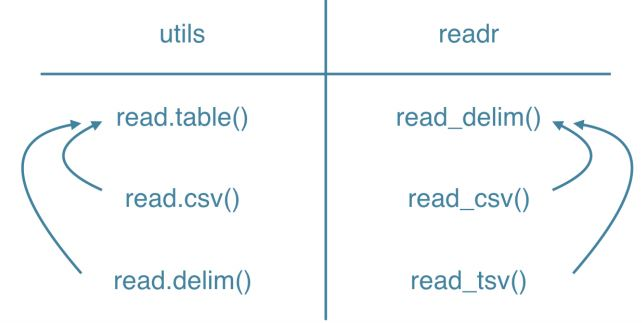

Now working with another dataset: *potatoes.csv*. It gives information on the impact of storage period and cooking on potatoes’ flavor. It uses commas to delimit fields in a record, and contains column names in the first row. Import the “potatoes.csv” data:

```r
read_csv("potatoes.csv")
```

```
## # A tibble: 160 x 8
##     area  temp  size storage method texture flavor moistness
##    <dbl> <dbl> <dbl>   <dbl>  <dbl>   <dbl>  <dbl>     <dbl>
##  1     1     1     1       1      1     2.9    3.2       3
##  2     1     1     1       1      2     2.3    2.5       2.6
##  3     1     1     1       1      3     2.5    2.8       2.8
##  4     1     1     1       1      4     2.1    2.9       2.4
##  5     1     1     1       1      5     1.9    2.8       2.2
##  6     1     1     1       2      1     1.8    3         1.7
##  7     1     1     1       2      2     2.6    3.1       2.4
##  8     1     1     1       2      3     3      3         2.9
##  9     1     1     1       2      4     2.2    3.2       2.5
## 10     1     1     1       2      5     2      2.8       1.9
## # ... with 150 more rows
```

This time, the potatoes data comes in the form of a tab-separated values file: *potatoes.txt*.

```r
read_tsv("potatoes.txt")
```

```
## # A tibble: 159 x 8
##      `1` `1_1` `1_2` `1_3` `1_4` `2.9` `3.2` `3.0`
##    <dbl> <dbl> <dbl> <dbl> <dbl> <dbl> <dbl> <dbl>
##  1     1     1     1     1     2   2.3   2.5   2.6
##  2     1     1     1     1     3   2.5   2.8   2.8
##  3     1     1     1     1     4   2.1   2.9   2.4
##  4     1     1     1     1     5   1.9   2.8   2.2
##  5     1     1     1     2     1   1.8   3     1.7
##  6     1     1     1     2     2   2.6   3.1   2.4
##  7     1     1     1     2     3   3     3     2.9
##  8     1     1     1     2     4   2.2   3.2   2.5
##  9     1     1     1     2     5   2     2.8   1.9
## 10     1     1     1     3     1   1.8   2.6   1.5
## # ... with 149 more rows
```

This *.txt* file does not contain columns names in the first row. This can be specify manually.

```r
properties <- c("area", "temp", "size", "storage", "method", "texture", "flavor", "moistness")
potatoes <- read_tsv("potatoes.txt", col_names = properties)
head(potatoes)
```

```
## # A tibble: 6 x 8
##    area  temp  size storage method texture flavor moistness
##   <dbl> <dbl> <dbl>   <dbl>  <dbl>   <dbl>  <dbl>     <dbl>
## 1     1     1     1       1      1     2.9    3.2       3
## 2     1     1     1       1      2     2.3    2.5       2.6
## 3     1     1     1       1      3     2.5    2.8       2.8
## 4     1     1     1       1      4     2.1    2.9       2.4
## 5     1     1     1       1      5     1.9    2.8       2.2
## 6     1     1     1       2      1     1.8    3         1.7
```

Use the low-level `read_delim` from **readr** to read the *.txt* files with values using `/` as separators:

```r
read_delim("states2.txt", delim = "/")
```

```
## # A tibble: 5 x 4
##   state        capital    pop_mill area_sqm
##   <chr>        <chr>         <dbl>    <dbl>
## 1 South Dakota Pierre        0.853    77116
## 2 New York     Albany       19.7      54555
## 3 Oregon       Salem         3.97     98381
## 4 Vermont      Montpelier    0.627     9616
## 5 Hawaii       Honolulu      1.42     10931
```

`delim` argument specifies the character that is used to separate fields within a record. It is equivalent to the `sep` argument in `read.table()`. The output corresponds to the output of `read.table()` but **readr** version outputs a tibble again.

Also, strings are not imported as factors by default, so `stringsAsFactors` equivalent is not necessary.

```r
read_delim("states3.txt", delim ="/",
           col_names = FALSE) # first line is a record.
```

```
## # A tibble: 5 x 4
##   X1           X2             X3    X4
##   <chr>        <chr>       <dbl> <dbl>
## 1 South Dakota Pierre      0.853 77116
## 2 New York     Albany     19.7   54555
## 3 Oregon       Salem       3.97  98381
## 4 Vermont      Montpelier  0.627  9616
## 5 Hawaii       Honolulu    1.42  10931
```

You can also manually set `col_names` to a character vector. The names you pass will be used as the names of the columns, and the first line is read as a record.

```r
read_delim("states3.txt", delim = "/",
           col_names = c("state", "city", "pop", "area"))
```

```
## # A tibble: 5 x 4
##   state        city          pop  area
##   <chr>        <chr>       <dbl> <dbl>
## 1 South Dakota Pierre      0.853 77116
## 2 New York     Albany     19.7   54555
## 3 Oregon       Salem       3.97  98381
## 4 Vermont      Montpelier  0.627  9616
## 5 Hawaii       Honolulu    1.42  10931
```

`col_types` controls the column classes (similar to `colClasses` in **utils**). If `col_type` is set to `NULL`, the default, functions from **readr** will try to find the correct types themselves. You can manually set the types with a string, where each character denotes the class of the column: character, double, integer and logical. `_` skips the column as a whole.

```r
read_delim("states2.txt", delim = "/",
           col_types = "ccdi") # c: character, d: double, i: integer.
```

```
## # A tibble: 5 x 4
##   state        capital    pop_mill area_sqm
##   <chr>        <chr>         <dbl>    <int>
## 1 South Dakota Pierre        0.853    77116
## 2 New York     Albany       19.7      54555
## 3 Oregon       Salem         3.97     98381
## 4 Vermont      Montpelier    0.627     9616
## 5 Hawaii       Honolulu      1.42     10931
```

If you are working on huge flat files, say one million lines, yo mighr be interested in handling data in chunks of 50.000 lines, for example. This keeps your work tractable and you can easily follow up the progress of your algorithms. In **readr** you can do this with the combination of `skip` and `n_max`.

`n_max` controls which part of your flat file you’re actually importing into R. `skip`: specifies the number of lines you’re ignoring in the flat file before actually starting to import data.

```r
read_delim("states2.txt", delim = "/",
           col_names = c("state", "city", "pop", "area"),
           skip = 2, n_max = 3)
```

```
## # A tibble: 3 x 4
##   state    city          pop  area
##   <chr>    <chr>       <dbl> <dbl>
## 1 New York Albany     19.7   54555
## 2 Oregon   Salem       3.97  98381
## 3 Vermont  Montpelier  0.627  9616
```

Use `read_delim` to import *potatoes.txt* instead of `read_tsv`:

```r
read_delim("potatoes.txt", delim = "\t",
           col_names = properties)
```

```
## # A tibble: 160 x 8
##     area  temp  size storage method texture flavor moistness
##    <dbl> <dbl> <dbl>   <dbl>  <dbl>   <dbl>  <dbl>     <dbl>
##  1     1     1     1       1      1     2.9    3.2       3
##  2     1     1     1       1      2     2.3    2.5       2.6
##  3     1     1     1       1      3     2.5    2.8       2.8
##  4     1     1     1       1      4     2.1    2.9       2.4
##  5     1     1     1       1      5     1.9    2.8       2.2
##  6     1     1     1       2      1     1.8    3         1.7
##  7     1     1     1       2      2     2.6    3.1       2.4
##  8     1     1     1       2      3     3      3         2.9
##  9     1     1     1       2      4     2.2    3.2       2.5
## 10     1     1     1       2      5     2      2.8       1.9
## # ... with 150 more rows
```

Import observations 7, 8, 9, 10 and 11 only:

```r
read_delim("potatoes.txt", delim = "\t",
           skip = 6, n_max = 5,
           col_names = properties)
```

```
## # A tibble: 5 x 8
##    area  temp  size storage method texture flavor moistness
##   <dbl> <dbl> <dbl>   <dbl>  <dbl>   <dbl>  <dbl>     <dbl>
## 1     1     1     1       2      2     2.6    3.1       2.4
## 2     1     1     1       2      3     3      3         2.9
## 3     1     1     1       2      4     2.2    3.2       2.5
## 4     1     1     1       2      5     2      2.8       1.9
## 5     1     1     1       3      1     1.8    2.6       1.5
```

You can specify which types the columns with `col_types`. If `col_type` is set to `NULL`, the default, functions from **readr** will try to find the correct types themselves. You can manually set the types with a string, where each character denotes the class of the column: character, double, integer and logical. _ skips the column as a whole.

```r
potatoes_char <- read_tsv("potatoes.txt", col_types = "cccccccc", col_names = properties)
str(potatoes_char)
```

```
## tibble [160 x 8] (S3: spec_tbl_df/tbl_df/tbl/data.frame)
##  $ area     : chr [1:160] "1" "1" "1" "1" ...
##  $ temp     : chr [1:160] "1" "1" "1" "1" ...
##  $ size     : chr [1:160] "1" "1" "1" "1" ...
##  $ storage  : chr [1:160] "1" "1" "1" "1" ...
##  $ method   : chr [1:160] "1" "2" "3" "4" ...
##  $ texture  : chr [1:160] "2.9" "2.3" "2.5" "2.1" ...
##  $ flavor   : chr [1:160] "3.2" "2.5" "2.8" "2.9" ...
##  $ moistness: chr [1:160] "3.0" "2.6" "2.8" "2.4" ...
##  - attr(*, "spec")=
##   .. cols(
##   ..   area = col_character(),
##   ..   temp = col_character(),
##   ..   size = col_character(),
##   ..   storage = col_character(),
##   ..   method = col_character(),
##   ..   texture = col_character(),
##   ..   flavor = col_character(),
##   ..   moistness = col_character()
##   .. )
```

Another way of setting the types of the imported columns is using collectors. Collector functions can be passed in a `list()` to the `col_types` argument of `read_` function to tell them how to interpret values in a column.

- `col_integer()`: the column should be interpreted as an integer.
- `col_factor(levels, ordered = FALSE)`: the column should be interpreted as a factor with levels.

Work with *hotdogs.txt* data, which is a tab-delimited file without column names in the first row.

```r
hotdogs <- read_tsv("hotdogs.txt",
                    col_names = c("type", "calories", "sodium"))
summary(hotdogs)
```

```
##      type              calories         sodium
##  Length:54          Min.   : 86.0   Min.   :144.0
##  Class :character   1st Qu.:132.0   1st Qu.:362.5
##  Mode  :character   Median :145.0   Median :405.0
##                     Mean   :145.4   Mean   :424.8
##                     3rd Qu.:172.8   3rd Qu.:503.5
##                     Max.   :195.0   Max.   :645.0
```

Define collector functions:

```r
fac <- col_factor(levels = c("Beef", "Meat", "Poultry"))
int <- col_integer()
```

Edit the `col_types` argument to import the data correctly:

```r
hotdogs_factor <- read_tsv("hotdogs.txt",
                           col_names = c("type", "calories", "sodium"),
                           col_types = list(fac, int, int))
summary(hotdogs_factor)
```

```
##       type       calories         sodium
##  Beef   :20   Min.   : 86.0   Min.   :144.0
##  Meat   :17   1st Qu.:132.0   1st Qu.:362.5
##  Poultry:17   Median :145.0   Median :405.0
##               Mean   :145.4   Mean   :424.8
##               3rd Qu.:172.8   3rd Qu.:503.5
##               Max.   :195.0   Max.   :645.0
```

### 1.7 data.table: fread

The key performance metric for **data.table** package by Matt Dowle and Arun Srinvasan is speed. The package is mainly about data manipulation in R, but also features a super powerful function to read data: `fread()`.

```r
library(data.table)
```

`fread()` is similar to `read.table()` but more convenient to use. Call `fread()` on *states.csv* with the first line as column names, and *states2.csv* without column names, both without additional arguments.

```r
fread("states.csv")
```

```
##           state    capital pop_mill area_sqm
## 1: South Dakota     Pierre    0.853    77116
## 2:     New York     Albany   19.746    54555
## 3:       Oregon      Salem    3.970    98381
## 4:      Vermont Montpelier    0.627     9616
## 5:       Hawaii   Honolulu    1.420    10931
```

```r
fread("states2.csv") # fread makes up some column names itself.
```

```
##              V1         V2     V3    V4
## 1: South Dakota     Pierre  0.853 77116
## 2:     New York     Albany 19.746 54555
## 3:       Oregon      Salem  3.970 98381
## 4:      Vermont Montpelier  0.627  9616
## 5:       Hawaii   Honolulu  1.420 10931
```

`fread()` automatically deals with both cases without any specific arguments. It can also infer column types and the field separators without having to specify these. You can also manually specify the separator, the `colClasses`, the number of lines to skip or to read manually. `fread` is like an improved version of `read.table` which is faster, more convenient and adds functionality.

Import *potatoes.csv* with `fread()`:

```r
fread("potatoes.csv")
```

```
##      area temp size storage method texture flavor moistness
##   1:    1    1    1       1      1     2.9    3.2       3.0
##   2:    1    1    1       1      2     2.3    2.5       2.6
##   3:    1    1    1       1      3     2.5    2.8       2.8
##   4:    1    1    1       1      4     2.1    2.9       2.4
##   5:    1    1    1       1      5     1.9    2.8       2.2
##  ---
## 156:    2    2    2       4      1     2.7    3.3       2.6
## 157:    2    2    2       4      2     2.6    2.8       2.3
## 158:    2    2    2       4      3     2.5    3.1       2.6
## 159:    2    2    2       4      4     3.4    3.3       3.0
## 160:    2    2    2       4      5     2.5    2.8       2.3
```

Import only columns 6 and 8 of *potatoes.csv*:

```r
fread("potatoes.csv", select = c(6, 8))
```

```
##      texture moistness
##   1:     2.9       3.0
##   2:     2.3       2.6
##   3:     2.5       2.8
##   4:     2.1       2.4
##   5:     1.9       2.2
##  ---
## 156:     2.7       2.6
## 157:     2.6       2.3
## 158:     2.5       2.6
## 159:     3.4       3.0
## 160:     2.5       2.3
```

or using the column names:

```r
potatoes <- fread("potatoes.csv", select = c("texture", "moistness"))
```

Plot texture `x` and moistness `y` of potatoes:

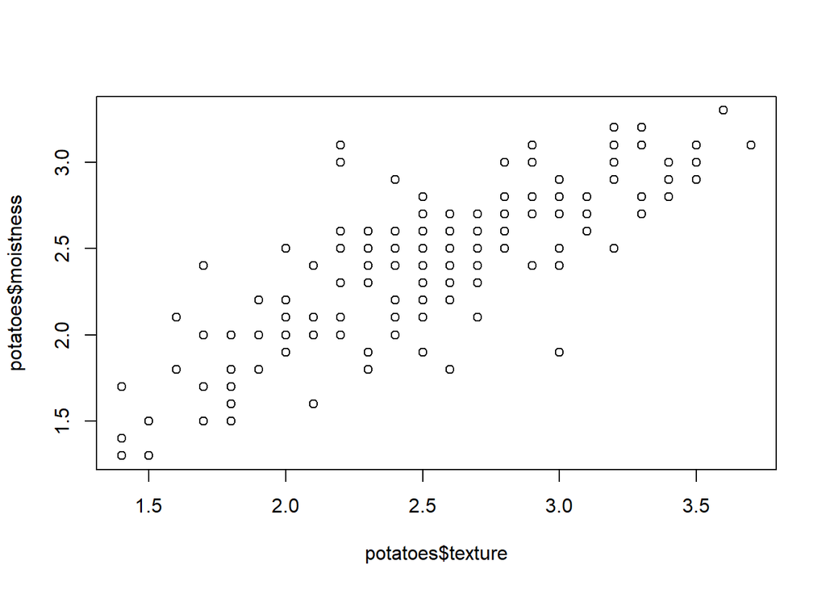

```r
plot(potatoes$texture, potatoes$moistness)
```